calibrateR is a package designed to streamline common laboratory calculations and provide an easy way to estimate parameters and values useful to a variety of experiments.

### Description

calibrateR is a package written to streamline common laboratory calculations. At the moment, this includes SEC calibration, BCA calibration, protein and nucleic acid concentration determination using UV/Vis spectroscopy, and the estimation of protein parameters given just a primary amino acid sequence.

### Example files

More in-depth example usage of calibrateR that goes through more of the function options is provided on [GitHub](https://github.com/gbedwell/example_files).

### Installation

```r
devtools::install_github("gbedwell/calibrateR")
```

### SEC calibration

There are two primary outputs for the `sec()` function:

1. A calibration output that calculates a standard curve given the necessary calibrant information.
2. An analytical output that estimates the molecular weight and hydrodynamic radius of a given analyte.

Both outputs can be generated in either tabular or graphical forms.

#### Generating a calibration curve

At least 3 different pieces of information are required for calibrateR to generate a calibration curve for a size-exclusion column:

1. The position of the column void volume. This is defined as `void` in the `sec` function. This can be empirically defined by running the polymer blue dextran over the column.
2. The column volume. This is defined as `cv` in the `sec()` function. This can be empirically defined by running something like 0.2% (v/v) acetone over the column.
3. The masses (`masses`) and elution volumes (`stds`) of a series of standard proteins. If using the commonly used BioRad gel filtration standards, the `masses` flag can be left `NULL`.

Toggle between tabular and graphical outputs with the `plot` flag. Setting `plot = “yes”` will generate graphical output. `plot = “no”` generates tabular output. Tabular output includes linear regression information.

To generate the calibration curve, set `type = “cal”`.

The hydrodynamic radii of the standard proteins are estimated based on their masses using the relationship described by Uversky (Biochemistry. 1993. 32. 13288-13298).

```r
sec(masses = c(669000, 158000, 44000, 17000, 1350),
    void = 1.87,
    cv = 4.29,
    stds = c(2.08,2.58,2.98,3.30,4.06),
    unk = NULL,
    plot = "no",
    type = "cal")
```

```
## Using defined mass values instead of default values!
```

| mw.da | rh.nm | standards.ev | ve.v0 | K.av | mw.pred | mw.lwr | mw.upr | rh.pred | rh.lwr | rh.upr | mw.r.sq | rh.r.sq |
| --- | --- | --- | --- | --- | --- | --- | --- | --- | --- | --- | --- | --- |
| 669000 | 7.863 | 2.08 | 0.21 | 0.087 | 723568.806 | 593856.666 | 881613.102 | 8.094 | 7.525 | 8.706 | 0.999 | 0.999 |
| 158000 | 4.616 | 2.58 | 0.71 | 0.293 | 150680.839 | 131366.181 | 172835.315 | 4.536 | 4.312 | 4.772 | 0.999 | 0.999 |
| 44000 | 2.880 | 2.98 | 1.11 | 0.459 | 42945.789 | 38233.659 | 48238.669 | 2.855 | 2.735 | 2.980 | 0.999 | 0.999 |
| 17000 | 2.028 | 3.30 | 1.43 | 0.591 | 15732.967 | 13852.108 | 17869.212 | 1.971 | 1.880 | 2.066 | 0.999 | 0.999 |
| 1350 | 0.796 | 4.06 | 2.19 | 0.905 | 1448.937 | 1165.482 | 1801.331 | 0.817 | 0.754 | 0.886 | 0.999 | 0.999 |

#### Estimating analyte properties

Setting `type = “pred”` will predict the molecular weights and hydrodynamic radii of unknown samples. This is based on the calculated standard curve and analyte elution volumes.

Define the analyte elution volumes as `unk` in the function.

In the graphical output, analyte parameters are reported in labels on the plot itself.

```
## Using defined mass values instead of default values!
##
## Molecular weight and radius LABELS appearing on the plot are NOT log-transformed!
##
## NOTE THAT THE ACTUAL POINTS ARE STILL AT LOG-TRANSFORMED POSITIONS!
```

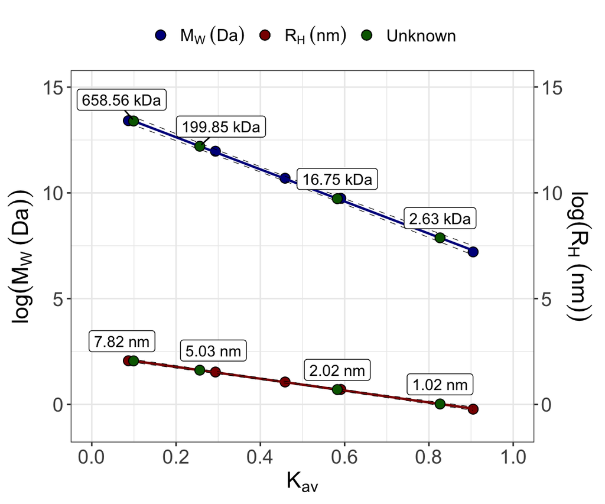

```r
sec(masses = c(669000, 158000, 44000, 17000, 1350),
    void = 1.87,
    cv = 4.29,
    stds = c(2.08,2.58,2.98,3.30,4.06),
    unk = c(2.11, 2.49, 3.28, 3.87),
    plot = "yes",
    type = "pred")
```

### BCA calibration

The function for BCA calibration (`bca()`) is generally similar to the `sec()` function.

The function minimally requires:

1. The known concentrations and corresponding absorbance values for a standard dilution series (`prot.conc` and `std.abs`).
2. The absorbance value of the buffer-only control (`blank.abs`).

```r
bca(prot.conc = c(2, 1.5, 1, 0.75, 0.5, 0.25, 0.125, 0.025),
    blank.abs = 0.1813,
    std.abs = c(2.4644, 1.989, 1.4295, 1.1075, 0.8124, 0.499, 0.3655, 0.2315),
    abs = NULL,
    dil.fac = NULL,
    plot = "no",
    type = "cal")
```

| conc | abs | corr.abs | conc.pred | conc.lwr | conc.upr | r.sq |
| --- | --- | --- | --- | --- | --- | --- |
| 2.000 | 2.464 | 2.283 | 1.945 | 1.884 | 2.007 | 0.998 |
| 1.500 | 1.989 | 1.808 | 1.532 | 1.486 | 1.577 | 0.998 |
| 1.000 | 1.430 | 1.248 | 1.045 | 1.013 | 1.077 | 0.998 |
| 0.750 | 1.107 | 0.926 | 0.765 | 0.735 | 0.794 | 0.998 |
| 0.500 | 0.812 | 0.631 | 0.508 | 0.476 | 0.540 | 0.998 |
| 0.250 | 0.499 | 0.318 | 0.235 | 0.197 | 0.273 | 0.998 |
| 0.125 | 0.366 | 0.184 | 0.119 | 0.077 | 0.161 | 0.998 |
| 0.025 | 0.232 | 0.050 | 0.002 | -0.044 | 0.048 | 0.998 |

To estimate the protein concentration in unknown samples, the absorbance values and dilution factor the sample(s) must also be defined (`abs` and `dil.fac`).

The `plot` and `type` flags operated identically to the `sec` function.

```
## The concentrations reported as labels on the plot are the DF CORRECTED values!
##
## These represent the final values that should usually be used in downstream calculations!
##
## For multiple dilutions of the same sample, the mean of these values should be calculated.
```

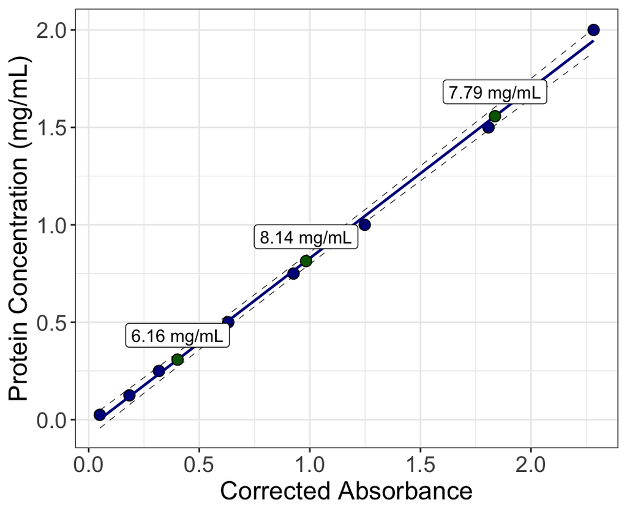

```r
bca(prot.conc = c(2, 1.5, 1, 0.75, 0.5, 0.25, 0.125, 0.025),
    blank.abs = 0.1813,
    std.abs = c(2.4644, 1.989, 1.4295, 1.1075, 0.8124, 0.499, 0.3655, 0.2315),
    abs = c(2.0184, 1.1641, 0.5831),
    dil.fac = c(5, 10, 20),
    plot = "yes",
    type = "pred")
```

### Protein parameter estimation

Protein parameter estimation from the primary amino acid sequence is a useful tool for any protein chemist. There are numerous webtools that estimate various parameters in this way. The `prot.param()` function in calibrateR calculates many standard parameters as well as some less common parameters that are useful for hydrodynamic analyses.

To estimate these parameters, first define the primary amino acid sequence of the protein-of-interest.

Next, define the temperature at which the experiments are being performed. This is important for the estimation of the protein’s partial specific volume (vbar) and associated parameters (e.g. the radius of a sphere with equal mass and density).

```r
protein <- c("MSKGEELFTGVVPILVELDGDVNGHKFSVRGEGEGDATNGKLTLKFICTTGKLPVPWPTL
VTTLTYGVQCFSRYPDHMKRHDFFKSAMPEGYVQERTISFKDDGTYKTRAEVKFEGDTLV
NRIELKGIDFKEDGNILGHKLEYNFNSHNVYITADKQKNGIKANFKIRHNVEDGSVQLAD
HYQQNTPIGDGPVLLPDNHYLSTQSVLSKDPNEKRDHMVLLEFVTAAGITHGMDELYK")

calibrateR::prot.param(protein, temp=25)
```

| parameter | value |
| --- | --- |
| number of residues | 238.000 |
| isotopically averaged mass (Da) | 26780.874 |
| monoisotopic mass (Da) | 26764.436 |
| vbar at temp (mL/g) | 0.735 |
| folded molar ext. coeff. at 280 nm (OD/mol*cm) in H2O | 19160.000 |
| unfolded molar ext. coeff. at 280 nm (OD/mol*cm) in 6 M GuHCl | 17450.000 |
| molar ext. coeff. at 205 nm (OD/mol*cm) in water | 909360.000 |
| radius of sphere with equal mass and density (nm) | 1.984 |
| est. denatured radius (nm) | 5.001 |
| est. globular radius (nm) | 2.322 |

[output not shown]